# homework1

Lemma1:(Hoeffding Lemma)  
Proof:  
Due to $f(X)=e^{sX}$ is a convex function ,so we have $e^{sX} \le \frac{b-X}{b-a}e^{sa}+\frac{X-a}{b-a}e^{sb}$  
And the expectiones of each side are satisfy inequality,so $E(e^{sX}) \le \frac{b-E(X)}{b-a}e^{sa}+\frac{E(X)-a}{b-a}e^{sb}=\frac{b}{b-a}e^{sa}-\frac{a}{b-a}e^{sb}$  
It's trivial that $a<0, b>0$, so $\frac{b}{b-a}e^{sa}-\frac{a}{b-a}e^{sb}>0$  
In fact, we have $\frac{b}{b-a}e^{sa}-\frac{a}{b-a}e^{sb}=e^{sa}(\frac{b}{b-a}-\frac{a}{b-a}e^{s(b-a)})=exp\left\{sa+ \ln {(\frac{b}{b-a}-\frac{a}{b-a}e^{s(b-a)})}\right\}$  
Let $p=\frac{b}{b-a}, q=s(b-a)$, so $exp\left\{sa+ \ln {(\frac{b}{b-a}-\frac{a}{b-a}e^{s(b-a)})}\right\}=exp\left\{(p-1)q+ \ln {(p+(1-p)e^q)}\right\}$  
Consider the function: $g(q)=(p-1)q+ \ln {(p+(1-p)e^q)}$  
$g'(q)=p-\frac{p}{p+(1-p)e^q}$ , $g''(q)=\frac{p(1-p)e^q}{[p+(1-p)e^q]^2} \le \frac{1}{4}$  
By Taylor's Folmula ,we have $g(q)=g(0)+g'(0)q+g''(\xi)\frac{q^2}{2}(0<\xi<q)$  
Thus, $E(e^{sX}) \le exp\left\{\frac{s^2(b-a)^2}{8}\right\}$ $Q.E.D$

Problem2 proof:  
(a):  
Let $A=\begin{bmatrix} a_{11} & \cdots & a_{1n} \\ \vdots & \ddots & \vdots \\ a_{m1} & \cdots & a_{mn} \end{bmatrix}$ and $x^T=\begin{bmatrix} x_1 & \cdots & x_n \end{bmatrix}$  
So $y=Ax\Rightarrow y^T=\begin{bmatrix} \sum_{i=1}^n a_{1i}x_i & \cdots & \sum_{i=1}^n a_{mi}x_{i} \end{bmatrix}$  
Accoding to backgroud, we have $\frac{\partial y}{\partial x^T}=\begin{bmatrix} \frac{\partial \sum_{i=1}^n a_{1i}x_i}{\partial x_1} & \cdots & \frac{\partial \sum_{i=1}^n a_{1i}x_i}{\partial x_n} \\ \vdots & \ddots & \vdots \\ \frac{\partial \sum_{i=1}^n a_{mi}x_i}{\partial x_1} & \cdots & \frac{\partial \sum_{i=1}^n a_{mi}x_i}{\partial x_n} \end{bmatrix}=\begin{bmatrix} a_{11} & \cdots & a_{1n} \\ \vdots & \ddots & \vdots \\ a_{m1} & \cdots & a_{mn} \end{bmatrix}=A$

(b):  
Notice that $\alpha = y^TAx = (y^TAx)^T = x^TA^Ty$  
Let $y^T = \begin{bmatrix} y_1 & \cdots & y_m \end{bmatrix}$  
We have $\frac{\partial \alpha}{\partial x^T}=\frac{\partial (x^TA^T)}{\partial x^T}y + x^TA^T\frac{\partial y}{\partial x^T}$  
Also notice that $\frac{\partial (x^TA^T)}{\partial x^T}y = \begin{bmatrix} \sum_{i=1}^m a_{i1}y_i & \cdots & \sum_{i=1}^m a_{im}y_i \end{bmatrix}=y^TA$  
Thus, we have $\frac{\partial \alpha}{\partial x^T}=x^TA^T(\frac{\partial y}{\partial x^T}) + y^TA$

(c):  
Use the conclusion of (b):  
Let $y=x$, we have $\frac{\partial y}{\partial x^T} = \frac{\partial x}{\partial x^T} = I_n$  
Thus, $\frac{\partial \alpha}{\partial x^T} = x^TA^TI_n + x^TA = x^T(A+A^T)$

(d):  
Assume that $x=Bz$, $B$ is $n \times q$, such that $\alpha=y^TABz$  
Use the conclution of (a) and (b),we can see $\frac{\partial \alpha}{\partial z^T} = z^T(AB)^T(\frac{\partial y}{\partial z^T})+y^TAB=x^TA^T(\frac{\partial y}{\partial z^T})+y^TA(\frac{\partial x}{\partial z^T})$

(e):  
Notice that $\frac{\partial I_n}{\partial \alpha}= \frac{\partial A^{-1}A}{\partial \alpha} = \frac{\partial A^{-1}}{\partial \alpha}A+A^{-1}\frac{\partial A}{\partial \alpha} = 0$  
It's easy to see that $\frac{\partial A^{-1}}{\partial \alpha} = -A^{-1}\frac{\partial A}{\partial \alpha}A^{-1}$

$Q.E.D$

[figure not shown]

```python
from IPython.display import Image
Image('./example.jpeg', width=400, height=200)
```

```python
print('Hello, World!')
```

```
Hello, World!
```

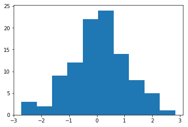

```python
import numpy as np
from matplotlib import pyplot as plt
data = np.random.normal(loc=0, scale=1, size=100)
plt.hist(data)
plt.show()
```